Bayesian Statistics: Mixture Models Sample code for simulating from a Mixture Model (Week1 with Codes)

[®γσ, Lian Hu](https://englianhu.github.io/) ®

2021-05-22

**Theme Song**

[interactive chart not shown]

# 1 Setting

## 1.1 SCSS Setup

```r
# install.packages("remotes")
require('BBmisc')
#remotes::install_github("rstudio/sass")
lib('sass')
```

```
## sass
## TRUE
```

```
/* https://stackoverflow.com/a/66029010/3806250 */
h1 { color: #002C54; }
h2 { color: #2F496E; }
h3 { color: #375E97; }

/* ----------------------------------------------------------------- */
/* https://gist.github.com/himynameisdave/c7a7ed14500d29e58149#file-broken-gradient-animation-less */
.hover01 {
  /* color: #FFD64D; */
  background: linear-gradient(155deg, #EDAE01 0%, #FFEB94 100%);
  transition: all 0.45s;
  &:hover{
    background: linear-gradient(155deg, #EDAE01 20%, #FFEB94 80%);
    }
  }

.hover02 {
  color: #FFD64D;
  background: linear-gradient(155deg, #002C54 0%, #4CB5F5 100%);
  transition: all 0.45s;
  &:hover{
    background: linear-gradient(155deg, #002C54 20%, #4CB5F5 80%);
    }
  }

.hover03 {
  color: #FFD64D;
  background: linear-gradient(155deg, #A10115 0%, #FF3C5C 100%);
  transition: all 0.45s;
  &:hover{
    background: linear-gradient(155deg, #A10115 20%, #FF3C5C 80%);
    }
  }
```

```r
## https://stackoverflow.com/a/36846793/3806250
options(width = 999)
knitr::opts_chunk$set(class.source = 'hover01', class.output = 'hover02', class.error = 'hover03')
```

## 1.2 Setup

```r
if(!suppressPackageStartupMessages(require('BBmisc'))) {
  install.packages('BBmisc', dependencies = TRUE, INSTALL_opts = '--no-lock')
}
suppressPackageStartupMessages(require('BBmisc'))
# suppressPackageStartupMessages(require('rmsfuns'))

pkgs <- c('devtools', 'knitr', 'kableExtra', 'tidyr',
          'readr', 'lubridate', 'data.table', 'reprex',
          'timetk', 'plyr', 'dplyr', 'stringr', 'magrittr',
          'tdplyr', 'tidyverse', 'formattable',
          'echarts4r', 'paletteer')

suppressAll(lib(pkgs))
# load_pkg(pkgs)

## Set the timezone but not change the datetime
Sys.setenv(TZ = 'Asia/Tokyo')
## options(knitr.table.format = 'html') will set all kableExtra tables to be 'html', otherwise need to set the parameter on every single table.
options(warn = -1, knitr.table.format = 'html')#, digits.secs = 6)

## https://stackoverflow.com/questions/39417003/long-vectors-not-supported-yet-abnor-in-rmd-but-not-in-r-script
knitr::opts_chunk$set(message = FALSE, warning = FALSE)#,
                      #cache = TRUE, cache.lazy = FALSE)

rm(pkgs)
```

# 2 受講生によるテストの実施：Simulating from a Mixture Model

## 2.1 説明

Consider the code provided in the lesson “Sample code for simulating from a Mixture Model”:

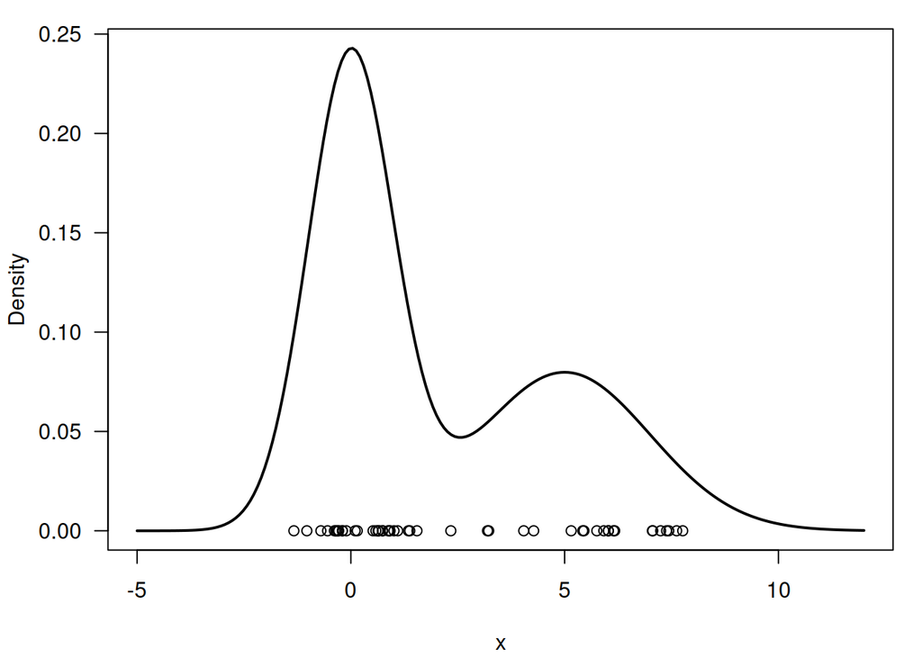

```r
# Sample code for simulating from a Mixture Model
# Generate n observations from a mixture of two Gaussian
# distributions
n     = 50           # Size of the sample to be generated
w     = c(0.6, 0.4)  # Weights
mu    = c(0, 5)      # Means
sigma = c(1, 2)      # Standard deviations
cc    = sample(1:2, n, replace=T, prob=w)
x     = rnorm(n, mu[cc], sigma[cc])

# Plot f(x) along with the observations
# just sampled
xx = seq(-5, 12, length=200)
yy = w[1]*dnorm(xx, mu[1], sigma[1]) +
  w[2]*dnorm(xx, mu[2], sigma[2])
par(mar=c(4,4,1,1)+0.1)
plot(xx, yy, type="l", ylab="Density", xlab="x", las=1, lwd=2)
points(x, y=rep(0,n), pch=1)
```

*Source : [Coursera-Bayesian-Statistics-Mixture-Models/Week1 Sample Code for Sim Mix Model.R](https://github.com/englianhu/Coursera-Bayesian-Statistics-Mixture-Models/blob/main/Week1%20Sample%20Code%20for%20Sim%20Mix%20Model.R)*

Modify the code above to sample 200 random numbers from a mixture of 3 Poisson distributions with means 1, 2 and 6 and weights 0.7, 0.2 and 0.1, respectively, and generate a barplot with the empirical frequencies of all the integers included in the sample.

### 2.1.1 Review criteria

The response should follow the same template as the sample code provided above. Peer reviewers will be asked to check whether the different pieces of code have been adequately modified to reflect the fact that (1) you are working now with 3 components rather than 2, (2) that the components of the mixture are Poisson distributions rather than Gaussians, (3) that the empirical frequencies associated with the sample generated are correctly computed, (4) that a barplot is used to represent the empirical frequencies.

## 2.2 自分の提出物

### 2.2.1 Assignment

### 2.2.2 Marking

## 2.3 ピアレビュー

### 2.3.1 1st Peer

#### 2.3.1.1 Assignment

Enter code to sample 200 random numbers from a mixture of 3 Poisson distributions with means 1, 2 and 6 and weights 0.7, 0.2 and 0.1, respectively.

```r
n     = 200               # Size of the sample to be generated
w     = c(0.7, 0.2, 0.1)  # Weights
lamba = c(1, 2, 6)        # Means
cc    = sample(1:3, n, replace=T, prob=w)
x     = rpois(n, lamba[cc])
```

Enter code to generate a barplot with the empirical frequencies of all the integers included in the sample.

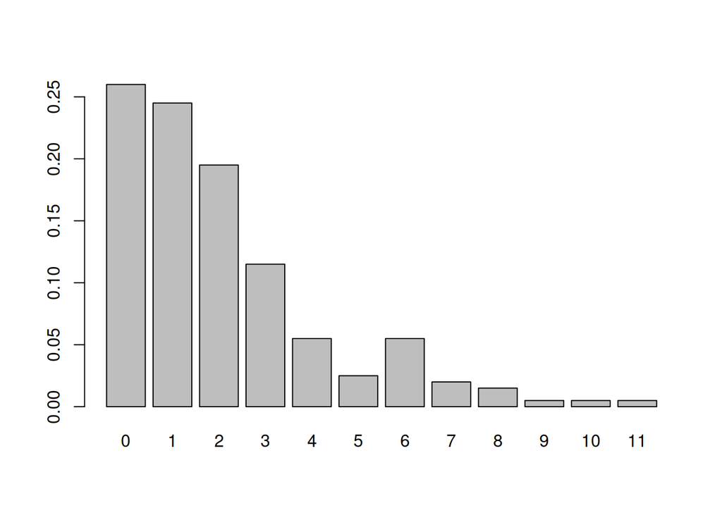

```r
empfreq = table(factor(x, levels=seq(0, max(x))))/n
barplot(empfreq)
```

#### 2.3.1.2 Marking

**Have the parameters of the mixture (both weights and component-specific parameters) been correctly specified?**

The lines

```r
n     = 50
w     = c(0.6, 0.4)  # Weights
mu    = c(0, 5)      # Means
sigma = c(1, 2)      # Standard deviations
```

in the original code should have been replaced by something like

```r
n      = 200
w      = c(0.7, 0.2, 0.1)  # Weights
lambda = c(1, 2, 6)        # Means
```

- 0点 No
- 1点 Yes

**Is the sampling of the indicator variables done correctly?**

The line

```r
cc    = sample(1:2, n, replace=T, prob=w)
```

```
## Error in sample.int(length(x), size, replace, prob): incorrect number of probabilities
```

```r
cc
```

```
##   [1] 1 3 1 3 2 3 2 1 1 1 3 1 2 1 1 3 3 3 1 1 1 1 1 1 2 2 2 1 1 1 1 2 1 1 1 1 2 1 1 1 1 1 1 1 1 1 2 1 1 1 3 1 1 3 3 1 1 2 1 2 1 2 2 1 1 2 1 1 1 3 1 3 3 1 3 1 1 2 1 1 2 3 2 1 1 1 1 2 2 3 2 1 3 3 1 1 3 1 1 2 1 1 2 1 1 1 3 1 1 1 1 2 2 1 1 1 1 1 1 3 1 1 1 2 1 1 1 1 2 1 1 1 1 1 3 1 1 2 2 1 2 1 1 2 1 2…
```

in the original code should now be something like

```r
cc    = sample(1:3, n, replace=T, prob=w)
cc
```

```
##   [1] 1 1 1 1 1 2 1 1 1 3 1 1 3 1 1 1 1 1 1 1 1 1 1 1 1 1 1 1 1 3 2 1 1 1 1 1 3 1 1 2 2 1 1 2 1 2 2 1 1 1 1 1 2 1 1 3 1 1 1 3 2 1 3 3 1 1 1 2 2 1 1 2 2 1 1 1 1 2 1 2 2 3 1 1 1 1 1 1 1 2 1 2 1 3 2 1 2 1 1 1 1 1 3 1 1 1 1 1 1 1 1 1 1 2 2 2 1 2 2 1 1 2 1 2 2 1 1 3 1 2 2 3 3 1 2 1 1 2 2 1 2 2 1 1 1 1…
```

to reflect the fact that we now have 3 components in the mixture.

- 0点 No
- 1点 Yes

**Assuming that the indicator variables have been correctly sampled, are the observations being sampled correctly?**

The line

```r
x     = rnorm(n, mu[cc], sigma[cc])
x
```

[output not shown]

should now be something like

```r
x     = rpois(n, lambda[cc])
x
```

```
##   [1]  3  1  0  1  0  1  0  2  1  4  1  1  4  1  0  2  1  1  0  1  0  1  1  4  1  1  0  2  1  4  2  1  2  2  1  0  8  0  2  2  1  2  1  5  2  2  2  2  2  2  2  0  1  1  2  4  1  1  1  8  5  1  6  4  2  2  3  2  1  0  2  1  3  1  0  1  1  0  0  1  4  2  2  0  0  0  2  0  3  0  1  2  1  7  3  1  3 …
```

to reflect the fact that the components of the mixture are all Poisson distributions.

- 0点 No
- 1点 Yes

**Are the empirical frequencies computed correctly?**

The code used to compute the frequencies should look something like

```r
empfreq = table(factor(x, levels=seq(0, max(x))))/n
empfreq
```

```
##
##     0     1     2     3     4     5     6     7     8     9    10    11    12    13
## 0.230 0.340 0.240 0.070 0.050 0.025 0.015 0.010 0.015 0.000 0.000 0.000 0.000 0.005
```

The main difficulty here is how to properly compute the frequencies using R, rather than anything that is specific to mixture models. Using the function `table()` directly on the vector $x$ will ignore values with zero counts. Similarly, the function `tabulate()` will ignore the $x = 0$ case. First converting the vector $x$ into a factor while ensuring that any integer between 0 and the maximum in the sample are valid factors avoids the issue.

- 0点 No
- 1点 Yes for some datasets, but might fail. Use this category if, for example, the function table was used directly on $x$,

```r
empfreq = table(x)/n
empfreq
```

```
## x
##     0     1     2     3     4     5     6     7     8    13
## 0.230 0.340 0.240 0.070 0.050 0.025 0.015 0.010 0.015 0.005
```

Partial credit should also be given if counts rather than frequencies are reported (i.e., if the answer does not divide by $n$).

- 2点 Yes

**Does the barplot appear correct?**

The code should be something like

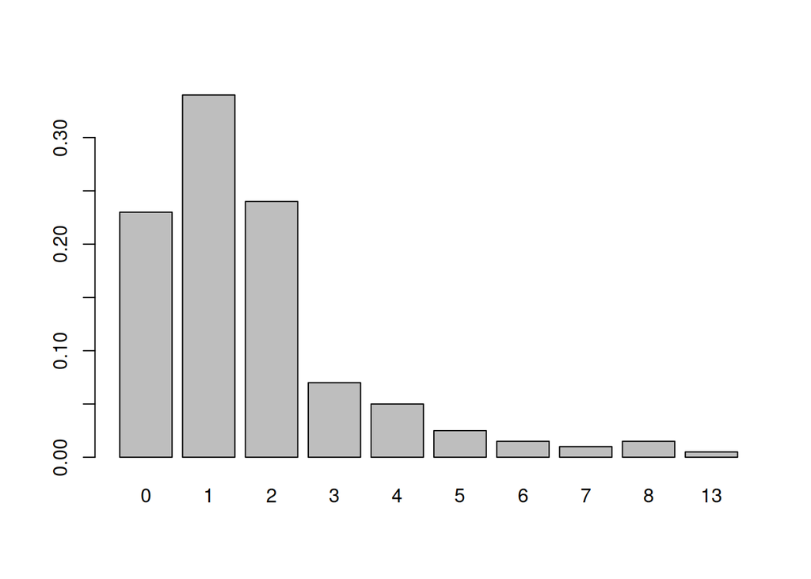

```r
barplot(empfreq)
```

or

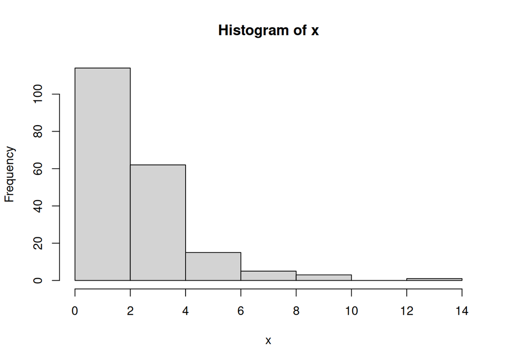

```r
hist(x, right=F)
```

- 0点 No
- 1点 Yes

### 2.3.2 2nd Peer

#### 2.3.2.1 Assignment

#### 2.3.2.2 Marking

### 2.3.3 3rd Peer

#### 2.3.3.1 Assignment

#### 2.3.3.2 Marking

## 2.4 ディスカッション

# 3 Appendix

## 3.1 Blooper

## 3.2 Documenting File Creation

It’s useful to record some information about how your file was created.

- File creation date: 2021-05-22
- File latest updated date: 2021-05-22
- R version 4.1.0 (2021-05-18)
- [**rmarkdown** package](https://github.com/rstudio/rmarkdown) version: 2.8
- File version: 1.0.0
- Author Profile: [®γσ, Eng Lian Hu](https://github.com/scibrokes/owner)
- GitHub: [Source Code](https://github.com/englianhu/coursera-bayesian-statistics-mixture-models)
- Additional session information:

```r
suppressMessages(require('dplyr', quietly = TRUE))
suppressMessages(require('magrittr', quietly = TRUE))
suppressMessages(require('formattable', quietly = TRUE))
suppressMessages(require('knitr', quietly = TRUE))
suppressMessages(require('kableExtra', quietly = TRUE))

sys1 <- devtools::session_info()$platform %>%
  unlist %>% data.frame(Category = names(.), session_info = .)
rownames(sys1) <- NULL

sys2 <- data.frame(Sys.info()) %>%
  dplyr::mutate(Category = rownames(.)) %>% .[2:1]
names(sys2)[2] <- c('Sys.info')
rownames(sys2) <- NULL

if (nrow(sys1) == 9 & nrow(sys2) == 8) {
  sys2 %<>% rbind(., data.frame(
  Category = 'Current time',
  Sys.info = paste(as.character(lubridate::now('Asia/Tokyo')), 'JST🗾')))
} else {
  sys1 %<>% rbind(., data.frame(
  Category = 'Current time',
  session_info = paste(as.character(lubridate::now('Asia/Tokyo')), 'JST🗾')))
}

sys <- cbind(sys1, sys2) %>%
  kbl(caption = 'Additional session information:') %>%
  kable_styling(bootstrap_options = c('striped', 'hover', 'condensed', 'responsive')) %>%
  row_spec(0, background = 'DimGrey', color = 'yellow') %>%
  column_spec(1, background = 'CornflowerBlue', color = 'red') %>%
  column_spec(2, background = 'grey', color = 'black') %>%
  column_spec(3, background = 'CornflowerBlue', color = 'blue') %>%
  column_spec(4, background = 'grey', color = 'white') %>%
  row_spec(9, bold = T, color = 'yellow', background = '#D7261E')

rm(sys1, sys2)
sys
```

Additional session information:

| Category | session_info | Category | Sys.info |
| --- | --- | --- | --- |
| version | R version 4.1.0 (2021-05-18) | sysname | Linux |
| os | Ubuntu 20.04.2 LTS | release | 5.8.0-54-generic |
| system | x86_64, linux-gnu | version | #61~20.04.1-Ubuntu SMP Thu May 13 00:05:49 UTC 2021 |
| ui | X11 | nodename | Scibrokes-Trading |
| language | en | machine | x86_64 |
| collate | en_US.UTF-8 | login | englianhu |
| ctype | en_US.UTF-8 | user | englianhu |
| tz | Asia/Tokyo | effective_user | englianhu |
| date | 2021-05-22 | Current time | 2021-05-22 03:31:07 JST🗾 |

## 3.3 Reference